# Statistical Analysis of Lana’s dataset

v4

Second version with additional variables

# General notes.

- I call all the IV predictors here. They are in %. i.e. 0.1 = 10%
- R2 describes the goodness of fit and how much of the data can be fitted by the regression hyperplane. To compensate for different number of predictors, we only use R_adj to compare different models (of different size). Attention: R2 does not say if any predictors explain the data in the model. We can have quite a good R2 but no significant predictors, or predictors with small effects. In the non-significant cases, we can probably still draw a conclusion for the current sample though (but not generalise)
- The correlations do not say anything about the goodnes of fit of the model in MLR.

# Data

## Data view

Let’s have a look at the original data. We remove several variables that, from a theortical consideration, are not relevant (and would sometimes cause collinearity) We also transform some values to a standard % format.

```r
#View(combined_analysis)
summary(combined_analysis)
```

```
##  country_code         Country          mean_progress_NREAP
##  Length:28          Length:28          Min.   :-0.39873
##  Class :character   Class :character   1st Qu.:-0.02436
##  Mode  :character   Mode  :character   Median : 0.08404
##                                        Mean   : 0.08329
##                                        3rd Qu.: 0.17828
##                                        Max.   : 0.49853
##                                        NA's   :1
##  renewed_mean_progress_linear_trajectory prioritization_scale
##  Min.   :-0.241566                       Min.   :0.00000
##  1st Qu.:-0.084135                       1st Qu.:0.05383
##  Median : 0.010059                       Median :0.11941
##  Mean   :-0.009362                       Mean   :0.16830
##  3rd Qu.: 0.047878                       3rd Qu.:0.21691
##  Max.   : 0.211580                       Max.   :0.56169
##  NA's   :1
##  Prio_EE_REN        mean_GDP_growth       PPS_2015      subsidies_REN
##  Length:28          Min.   :-0.02400   Min.   : 48.00   Min.   :0.03851
##  Class :character   1st Qu.: 0.01319   1st Qu.: 73.75   1st Qu.:0.16328
##  Mode  :character   Median : 0.02006   Median : 89.50   Median :0.40487
##                     Mean   : 0.02142   Mean   :101.14   Mean   :0.42378
##                     3rd Qu.: 0.03050   3rd Qu.:122.00   3rd Qu.:0.57221
##                     Max.   : 0.06389   Max.   :272.00   Max.   :1.01266
##
##  subsidies_savings     Jobs_EE            Jobs_REN
##  Min.   :0.000583   Min.   :0.000175   Min.   :0.000175
##  1st Qu.:0.027677   1st Qu.:0.005291   1st Qu.:0.002171
##  Median :0.052632   Median :0.008790   Median :0.004286
##  Mean   :0.107699   Mean   :0.010721   Mean   :0.005115
##  3rd Qu.:0.158954   3rd Qu.:0.011848   3rd Qu.:0.007412
##  Max.   :0.414384   Max.   :0.035225   Max.   :0.012680
##  NA's   :7          NA's   :2          NA's   :1
##  Policy_density_EE Policy_density_REN normalized_social_tech_potential
##  Min.   :0.1053    Min.   :0.0000     Min.   :0.1389
##  1st Qu.:0.2022    1st Qu.:0.1239     1st Qu.:0.6756
##  Median :0.2763    Median :0.1545     Median :1.1149
##  Mean   :0.2958    Mean   :0.1588     Mean   :1.5304
##  3rd Qu.:0.3624    3rd Qu.:0.1906     3rd Qu.:2.0617
##  Max.   :0.6000    Max.   :0.3511     Max.   :4.6738
##                                       NA's   :1
```

[output cut: 17 more lines]

```
##  Min.   :-0.03139   Min.   :-0.37826   Min.   :0.1338
##  1st Qu.: 0.10451   1st Qu.:-0.01846   1st Qu.:0.1721
##  Median : 0.11463   Median : 0.07783   Median :0.2026
##  Mean   : 0.11616   Mean   : 0.03823   Mean   :0.2103
##  3rd Qu.: 0.13633   3rd Qu.: 0.11796   3rd Qu.:0.2411
##  Max.   : 0.18707   Max.   : 0.23159   Max.   :0.3925
##
##  percent_size_industry percent_size_services
##  Min.   :0.0688        Min.   :0.1434
##  1st Qu.:0.1621        1st Qu.:0.1774
##  Median :0.1973        Median :0.2011
##  Mean   :0.1985        Mean   :0.2075
##  3rd Qu.:0.2518        3rd Qu.:0.2304
##  Max.   :0.3092        Max.   :0.3156
##
```

```r
combined_analysis_transformed <- combined_analysis %>%
  mutate(
    pre_potential_EI = pre_potential_EI / 100)
  # ) %>%
  # select(-subsidies_savings, - subsidies_REN, -percent_REN_economic, -percent_EE_economic, -percent_REN_planning, -percent_EE_planning)

summary(combined_analysis_transformed)
```

```
##  country_code         Country          mean_progress_NREAP
##  Length:28          Length:28          Min.   :-0.39873
##  Class :character   Class :character   1st Qu.:-0.02436
##  Mode  :character   Mode  :character   Median : 0.08404
##                                        Mean   : 0.08329
##                                        3rd Qu.: 0.17828
##                                        Max.   : 0.49853
##                                        NA's   :1
##  renewed_mean_progress_linear_trajectory prioritization_scale
##  Min.   :-0.241566                       Min.   :0.00000
##  1st Qu.:-0.084135                       1st Qu.:0.05383
##  Median : 0.010059                       Median :0.11941
##  Mean   :-0.009362                       Mean   :0.16830
##  3rd Qu.: 0.047878                       3rd Qu.:0.21691
##  Max.   : 0.211580                       Max.   :0.56169
##  NA's   :1
##  Prio_EE_REN        mean_GDP_growth       PPS_2015      subsidies_REN
##  Length:28          Min.   :-0.02400   Min.   : 48.00   Min.   :0.03851
##  Class :character   1st Qu.: 0.01319   1st Qu.: 73.75   1st Qu.:0.16328
##  Mode  :character   Median : 0.02006   Median : 89.50   Median :0.40487
##                     Mean   : 0.02142   Mean   :101.14   Mean   :0.42378
##                     3rd Qu.: 0.03050   3rd Qu.:122.00   3rd Qu.:0.57221
##                     Max.   : 0.06389   Max.   :272.00   Max.   :1.01266
##
##  subsidies_savings     Jobs_EE            Jobs_REN
##  Min.   :0.000583   Min.   :0.000175   Min.   :0.000175
##  1st Qu.:0.027677   1st Qu.:0.005291   1st Qu.:0.002171
##  Median :0.052632   Median :0.008790   Median :0.004286
##  Mean   :0.107699   Mean   :0.010721   Mean   :0.005115
##  3rd Qu.:0.158954   3rd Qu.:0.011848   3rd Qu.:0.007412
##  Max.   :0.414384   Max.   :0.035225   Max.   :0.012680
##  NA's   :7          NA's   :2          NA's   :1
##  Policy_density_EE Policy_density_REN normalized_social_tech_potential
##  Min.   :0.1053    Min.   :0.0000     Min.   :0.1389
##  1st Qu.:0.2022    1st Qu.:0.1239     1st Qu.:0.6756
##  Median :0.2763    Median :0.1545     Median :1.1149
##  Mean   :0.2958    Mean   :0.1588     Mean   :1.5304
##  3rd Qu.:0.3624    3rd Qu.:0.1906     3rd Qu.:2.0617
##  Max.   :0.6000    Max.   :0.3511     Max.   :4.6738
##                                       NA's   :1
```

[output cut: 17 more lines]

```
##  Min.   :-0.03139   Min.   :-0.37826   Min.   :0.1338
##  1st Qu.: 0.10451   1st Qu.:-0.01846   1st Qu.:0.1721
##  Median : 0.11463   Median : 0.07783   Median :0.2026
##  Mean   : 0.11616   Mean   : 0.03823   Mean   :0.2103
##  3rd Qu.: 0.13633   3rd Qu.: 0.11796   3rd Qu.:0.2411
##  Max.   : 0.18707   Max.   : 0.23159   Max.   :0.3925
##
##  percent_size_industry percent_size_services
##  Min.   :0.0688        Min.   :0.1434
##  1st Qu.:0.1621        1st Qu.:0.1774
##  Median :0.1973        Median :0.2011
##  Mean   :0.1985        Mean   :0.2075
##  3rd Qu.:0.2518        3rd Qu.:0.2304
##  Max.   :0.3092        Max.   :0.3156
##
```

## Remove missing cases

First we need to remove missing cases.

```
## [1] "For EE data: Of 28 cases 18 are left due to missing data,"
```

```
## [1] "For REN data: Of 28 cases 18 are left due to missing data,"
```

| countries | in_sample |
| --- | --- |
| AT | In the finale sample |
| BE | In the finale sample |
| BG | Missing |
| CY | Missing |
| CZ | In the finale sample |
| DE | In the finale sample |
| DK | In the finale sample |
| EE | In the finale sample |
| ES | In the finale sample |
| FI | In the finale sample |
| FR | In the finale sample |
| GB | In the finale sample |
| GR | Missing |
| HR | In the finale sample |
| HU | Missing |
| IE | Missing |
| IT | In the finale sample |
| LT | Missing |
| LU | Missing |
| LV | In the finale sample |
| MT | Missing |
| NL | Missing |
| PL | In the finale sample |
| PT | In the finale sample |
| RO | In the finale sample |
| SE | In the finale sample |
| SI | In the finale sample |
| SK | Missing |

[figure not shown]

Some data is missing that we can’t use in MLR, but most is there. Missing is percent_largest_generator for netherlands e.g.. TODO

## Marginal plots

Let’s have a look at the data using marginal plots. This helps to see if any (potential) predictores are skewed. If this is the case, log() transformation will be applied in the regression model, which is a standard procedure to improve the model.

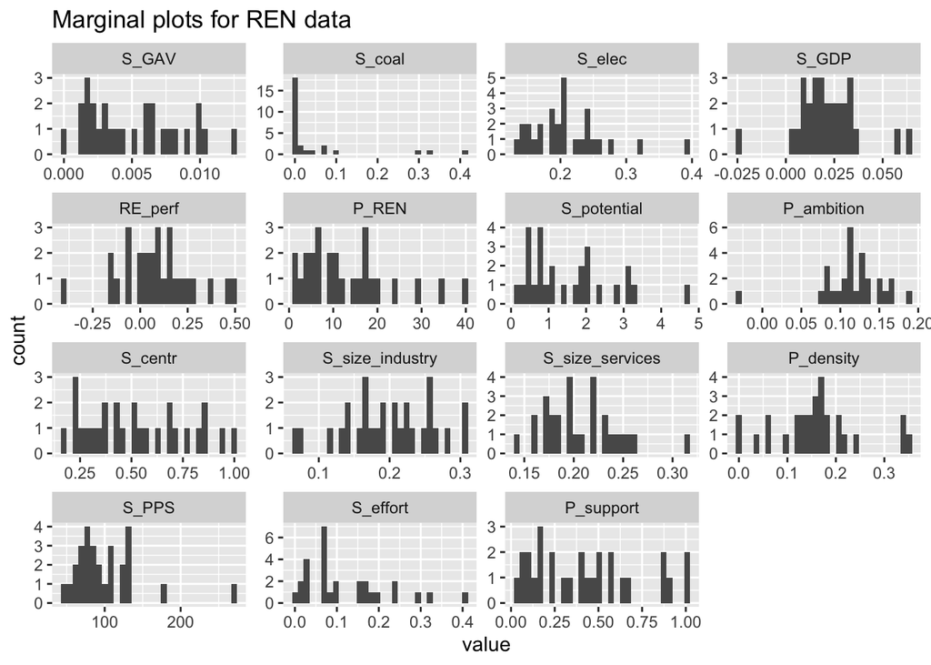

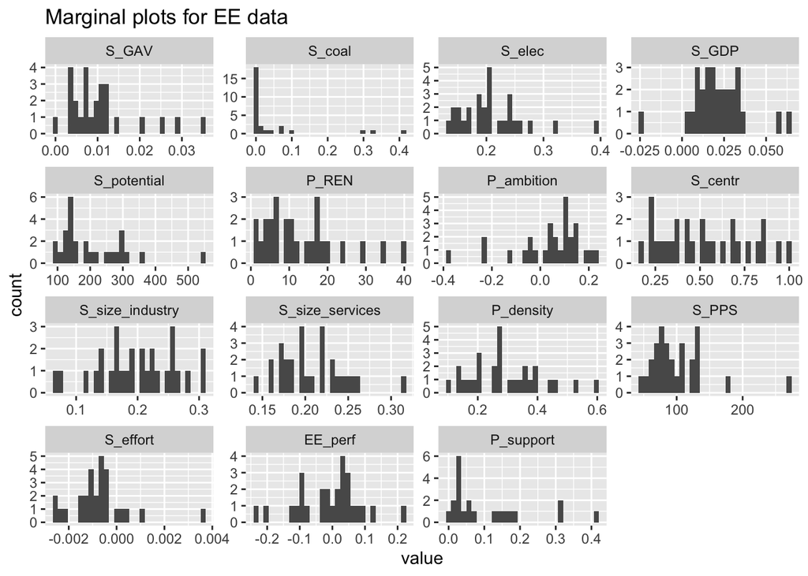

```r
Ren_both_effects[["wide_no_na"]] <- Ren_both_effects[["wide_no_na"]]


EE_both_effects[["wide_no_na"]] <- EE_both_effects[["wide_no_na"]]
```

# 1. REN Performance

## Full model construction

This model contains all possible IVs.

```r
formulas[["REN_perf_full"]] <- formula(RE_perf ~
    P_density + P_ambition + P_REN +
    S_GAV + S_potential + S_effort + S_PPS + S_elec  + S_centr + S_GDP)

full_models[["RE"]][["01_untransformed"]] <- lm(
  formula = formulas[["REN_perf_full"]], data = Ren_both_effects[["wide_no_na"]])


summary(full_models$RE$`01_untransformed`)
```

```
##
## Call:
## lm(formula = formulas[["REN_perf_full"]], data = Ren_both_effects[["wide_no_na"]])
##
## Residuals:
##       Min        1Q    Median        3Q       Max
## -0.151635 -0.042156 -0.009086  0.035952  0.151215
##
## Coefficients:
##              Estimate Std. Error t value Pr(>|t|)
## (Intercept)  0.067630   0.309563   0.218   0.8333
## P_density    0.621848   0.456824   1.361   0.2156
## P_ambition  -3.434397   1.086031  -3.162   0.0159 *
## P_REN        0.003986   0.004272   0.933   0.3819
## S_GAV       -6.819150  15.130625  -0.451   0.6658
## S_potential  0.115549   0.043285   2.669   0.0320 *
## S_effort     0.328923   0.470120   0.700   0.5067
## S_PPS        0.002981   0.002155   1.383   0.2091
## S_elec      -0.697450   1.285304  -0.543   0.6042
## S_centr     -0.193297   0.179726  -1.076   0.3178
## S_GDP        0.934099   5.762782   0.162   0.8758
## ---
## Signif. codes:  0 '***' 0.001 '**' 0.01 '*' 0.05 '.' 0.1 ' ' 1
##
## Residual standard error: 0.1256 on 7 degrees of freedom
## Multiple R-squared:  0.7852, Adjusted R-squared:  0.4784
## F-statistic: 2.559 on 10 and 7 DF,  p-value: 0.1126
```

## Collinearity check

The selection of variables is essential. The preferred way is to have some theorethical knowledge from other studies. For a good model, there must no be any large collinearitie between variables.

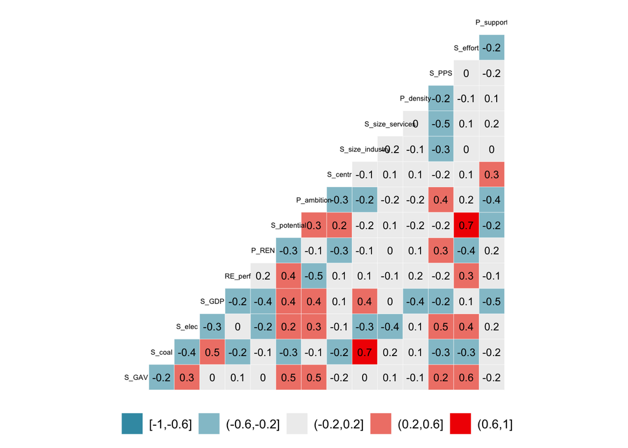

All correlations above 0.8 are problematic. We don’t find any. Let’s also check this numerically based on the full (transfomred) model.

```r
vif(full_models$RE$`01_untransformed`)
```

```
##   P_density  P_ambition       P_REN       S_GAV S_potential    S_effort
##    1.673030    2.604127    2.580626    2.814928    3.371512    2.806935
##       S_PPS      S_elec     S_centr       S_GDP
##    3.185963    3.317567    1.758374    3.145494
```

## Math variable selection

Let’s apply a stepwise backward selectin of variables to the full model to improve things.

```r
full_models[["RE"]][["03_selected"]] <- step(
  full_models[["RE"]][["01_untransformed"]], direction = "backward", trace = 0)
summary(full_models[["RE"]][["03_selected"]])
```

```
##
## Call:
## lm(formula = RE_perf ~ P_ambition + P_REN + S_potential, data = Ren_both_effects[["wide_no_na"]])
##
## Residuals:
##      Min       1Q   Median       3Q      Max
## -0.13201 -0.08797  0.01122  0.07650  0.16542
##
## Coefficients:
##              Estimate Std. Error t value Pr(>|t|)
## (Intercept)  0.165929   0.085342   1.944 0.072235 .
## P_ambition  -2.676432   0.608915  -4.395 0.000610 ***
## P_REN        0.005679   0.002455   2.313 0.036454 *
## S_potential  0.094028   0.022704   4.141 0.000998 ***
## ---
## Signif. codes:  0 '***' 0.001 '**' 0.01 '*' 0.05 '.' 0.1 ' ' 1
##
## Residual standard error: 0.1086 on 14 degrees of freedom
## Multiple R-squared:  0.6786, Adjusted R-squared:  0.6098
## F-statistic: 9.855 on 3 and 14 DF,  p-value: 0.0009426
```

## Checking Model assumptions

It is very important that some assumptions are fulfilled. Otherwise, the findings may be wrong and can not be generalised.

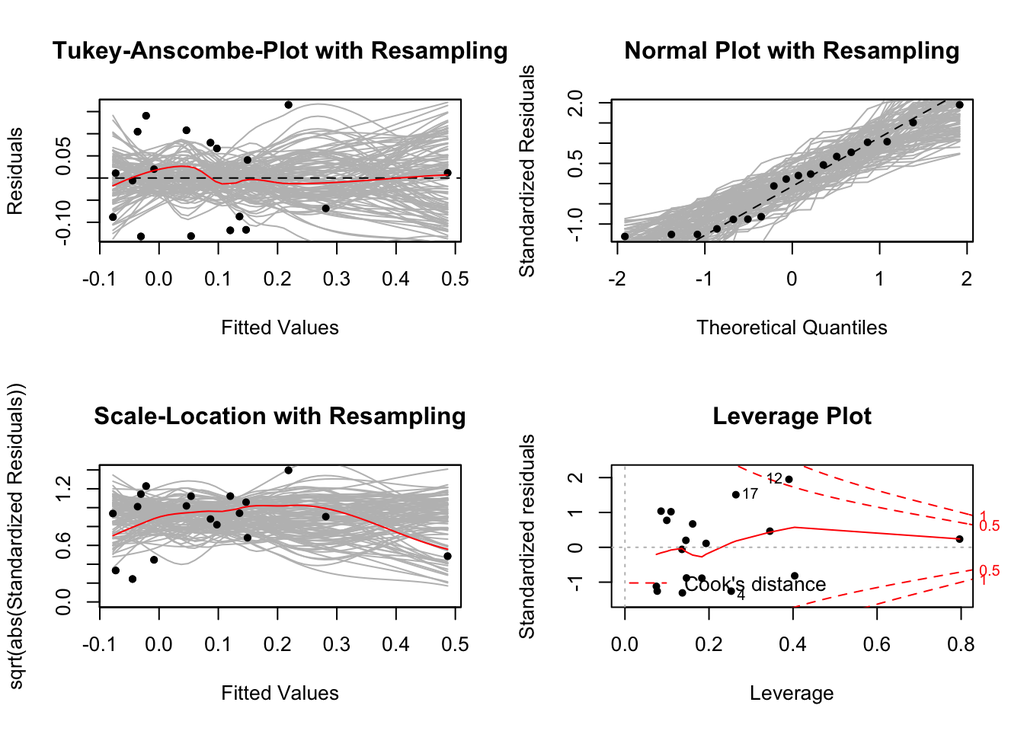

```r
resplot(full_models[["RE"]][["03_selected"]])
```

- Plot 1: The average error is probably 0 (within random resampled lines), which is good. There is no systematic error.
- Plot 2: Redsiduals are normall distributed, which is good
- Plot 3: There seems to be heteroskedasity, but random resampling suggests that this line could have be gotten by chance.
- Plot 4: There aren’t many influenctial cases. Good

All in all, statistical assumptions are fulfilled an the conclusions drawn from it are robust.

# 2. EE Performance

## Full model construction

This model contains all possible IVs.

```r
formulas[["EE_perf_full"]] <- formula(EE_perf ~
    P_density + P_ambition + P_REN +
    S_GAV + S_potential + S_effort + S_PPS + S_elec + S_centr  + S_GDP)

full_models[["EE"]][["01_untransformed"]] <- lm(
  formula = formulas[["EE_perf_full"]] , data = EE_both_effects[["wide_no_na"]])

summary(full_models$EE$`01_untransformed`)
```

```
##
## Call:
## lm(formula = formulas[["EE_perf_full"]], data = EE_both_effects[["wide_no_na"]])
##
## Residuals:
##       Min        1Q    Median        3Q       Max
## -0.083201 -0.017514  0.003179  0.024676  0.072695
##
## Coefficients:
##               Estimate Std. Error t value Pr(>|t|)
## (Intercept)  1.335e-01  2.526e-01   0.528   0.6136
## P_density    8.564e-02  1.594e-01   0.537   0.6077
## P_ambition  -2.807e-01  3.086e-01  -0.910   0.3933
## P_REN        1.807e-03  2.436e-03   0.742   0.4824
## S_GAV        2.862e+00  2.878e+00   0.994   0.3532
## S_potential -3.415e-04  4.630e-04  -0.738   0.4848
## S_effort    -3.124e+01  3.832e+01  -0.815   0.4419
## S_PPS       -2.581e-03  1.202e-03  -2.148   0.0688 .
## S_elec       3.925e-01  5.590e-01   0.702   0.5053
## S_centr      1.569e-02  1.431e-01   0.110   0.9158
## S_GDP       -1.752e-02  2.781e+00  -0.006   0.9952
## ---
## Signif. codes:  0 '***' 0.001 '**' 0.01 '*' 0.05 '.' 0.1 ' ' 1
##
## Residual standard error: 0.05871 on 7 degrees of freedom
## Multiple R-squared:  0.757,  Adjusted R-squared:   0.41
## F-statistic: 2.181 on 10 and 7 DF,  p-value: 0.1565
```

## Collinearity check

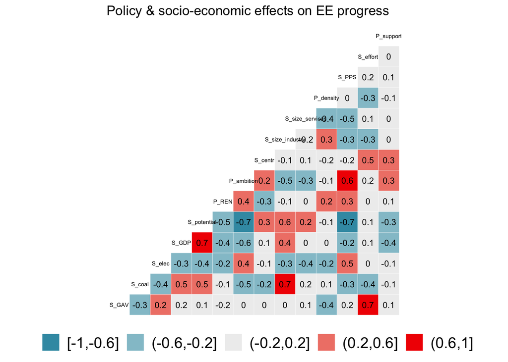

```r
GGally::ggcorr(EE_both_effects$wide_no_na %>% select(-EE_perf), nbreaks = 5, label = TRUE, size = 2,label_size = 3, legend.position = "bottom", legend.size = 15)  +
  ggtitle ("Policy & socio-economic effects on EE progress")
```

```r
vif(full_models$EE$`01_untransformed`)
```

```
##   P_density  P_ambition       P_REN       S_GAV S_potential    S_effort
##    1.370204    6.987882    3.842505    3.366360    6.609201    4.038212
##       S_PPS      S_elec     S_centr       S_GDP
##    4.533848    2.872770    5.100599    3.354245
```

## Math variable selection

Let’s apply a stepwise backward selection of variables to the full model.

```r
full_models[["EE"]][["03_selected"]] <- step(full_models[["EE"]][["01_untransformed"]], direction = "backward", trace = 0)
summary(full_models[["EE"]][["03_selected"]])
```

```
##
## Call:
## lm(formula = EE_perf ~ P_ambition + S_GAV + S_potential + S_effort +
##     S_PPS, data = EE_both_effects[["wide_no_na"]])
##
## Residuals:
##       Min        1Q    Median        3Q       Max
## -0.097585 -0.024831  0.009054  0.027953  0.072053
##
## Coefficients:
##               Estimate Std. Error t value Pr(>|t|)
## (Intercept)  2.922e-01  1.082e-01   2.701  0.01929 *
## P_ambition  -2.134e-01  1.533e-01  -1.392  0.18930
## S_GAV        2.652e+00  1.837e+00   1.444  0.17445
## S_potential -4.708e-04  2.554e-04  -1.844  0.09007 .
## S_effort    -3.211e+01  2.235e+01  -1.437  0.17637
## S_PPS       -2.539e-03  7.419e-04  -3.422  0.00506 **
## ---
## Signif. codes:  0 '***' 0.001 '**' 0.01 '*' 0.05 '.' 0.1 ' ' 1
##
## Residual standard error: 0.04905 on 12 degrees of freedom
## Multiple R-squared:  0.7093, Adjusted R-squared:  0.5882
## F-statistic: 5.857 on 5 and 12 DF,  p-value: 0.005759
```

## Checking Model assumptions

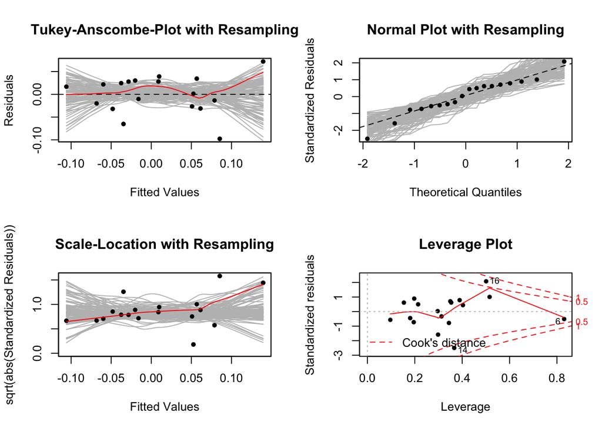

```r
resplot(full_models[["EE"]][["03_selected"]])
```

```r
# Check outlier
EE_both_effects[["wide_no_na"]] %>%
  slice(c(14, 6))
```

| country_code | S_GAV | S_coal | S_elec | S_GDP | S_potential | P_REN | P_ambition | S_centr | S_size_industry | S_size_services | P_density | S_PPS | S_effort | EE_perf | P_support |
| --- | --- | --- | --- | --- | --- | --- | --- | --- | --- | --- | --- | --- | --- | --- | --- |
| PL | 0.006950 | 0.4120188 | 0.1584135 | 0.033375 | 297.7150 | 6.20 | -0.22414088 | 0.1722000 | 0.2538 | 0.2572 | 0.2083333 | 69 | -0.001318437 | -0.01218117 | 0.02364865 |
| EE | 0.035225 | 0.0000000 | 0.2034843 | 0.036000 | 351.1467 | 1.74 | 0.02777778 | 0.8432222 | 0.2125 | 0.2222 | 0.1052632 | 77 | 0.001082738 | -0.02630777 | 0.05263158 |

# 3. REN Ambition

## Full model construction

This model contains all possible IVs.

```r
full_models[["RE_amb"]][["01_untransformed"]] <- lm(
  P_ambition ~
    P_density + P_REN +
    S_GAV + S_potential + S_effort + S_PPS + S_elec + S_centr  + S_GDP,
  data = Ren_both_effects[["wide_no_na"]] %>% filter(country_code != "HR"))

summary(full_models$RE_amb$`01_untransformed`)
```

```
##
## Call:
## lm(formula = P_ambition ~ P_density + P_REN + S_GAV + S_potential +
##     S_effort + S_PPS + S_elec + S_centr + S_GDP, data = Ren_both_effects[["wide_no_na"]] %>%
##     filter(country_code != "HR"))
##
## Residuals:
##       Min        1Q    Median        3Q       Max
## -0.028455 -0.004365  0.000417  0.005792  0.031244
##
## Coefficients:
##               Estimate Std. Error t value Pr(>|t|)
## (Intercept)  0.0812245  0.0634924   1.279   0.2416
## P_density    0.0994965  0.0808512   1.231   0.2582
## P_REN       -0.0004407  0.0007798  -0.565   0.5896
## S_GAV       -4.4711996  3.2932341  -1.358   0.2167
## S_potential  0.0180140  0.0083756   2.151   0.0685 .
## S_effort     0.1187047  0.0939141   1.264   0.2467
## S_PPS        0.0007254  0.0003630   1.999   0.0858 .
## S_elec      -0.1794976  0.2439374  -0.736   0.4858
## S_centr     -0.0303598  0.0316537  -0.959   0.3694
## S_GDP       -0.2284485  1.1215826  -0.204   0.8444
## ---
## Signif. codes:  0 '***' 0.001 '**' 0.01 '*' 0.05 '.' 0.1 ' ' 1
##
## Residual standard error: 0.02269 on 7 degrees of freedom
## Multiple R-squared:  0.693,  Adjusted R-squared:  0.2984
## F-statistic: 1.756 on 9 and 7 DF,  p-value: 0.2351
```

## Collinearity check

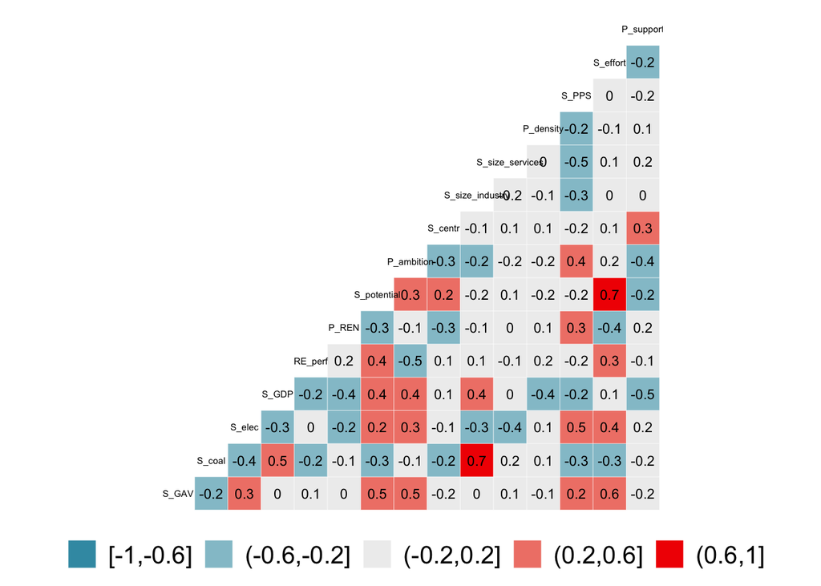

```r
GGally::ggcorr(Ren_both_effects$wide_no_na, nbreaks = 5, label = TRUE, size = 2,label_size = 3, legend.position = "bottom", legend.size = 15)
```

```r
vif(full_models$RE_amb$`01_untransformed`)
```

```
##   P_density       P_REN       S_GAV S_potential    S_effort       S_PPS
##    1.578413    2.582242    3.623494    3.838998    3.324841    2.419790
##      S_elec     S_centr       S_GDP
##    3.609862    1.428131    3.360552
```

S_potential may be slightly collinear with S_effort, however it’s still below 10. So not extremely problematic, but a bit if both variables will be in the final model.

## Math variable selection

Let’s apply a stepwise backward selection of variables to the full model.

```r
full_models[["RE_amb"]][["03_selected"]] <- step(full_models[["RE_amb"]][["01_untransformed"]], direction = "backward", trace = 0)
summary(full_models[["RE_amb"]][["03_selected"]])
```

```
##
## Call:
## lm(formula = P_ambition ~ S_GAV + S_potential + S_effort + S_PPS,
##     data = Ren_both_effects[["wide_no_na"]] %>% filter(country_code !=
##         "HR"))
##
## Residuals:
##       Min        1Q    Median        3Q       Max
## -0.031081 -0.013445  0.005188  0.010609  0.026155
##
## Coefficients:
##               Estimate Std. Error t value Pr(>|t|)
## (Intercept)  0.0654663  0.0223829   2.925   0.0127 *
## S_GAV       -3.2345937  2.2191986  -1.458   0.1706
## S_potential  0.0133783  0.0052327   2.557   0.0252 *
## S_effort     0.1011380  0.0689146   1.468   0.1679
## S_PPS        0.0004341  0.0002133   2.035   0.0646 .
## ---
## Signif. codes:  0 '***' 0.001 '**' 0.01 '*' 0.05 '.' 0.1 ' ' 1
##
## Residual standard error: 0.01955 on 12 degrees of freedom
## Multiple R-squared:  0.6094, Adjusted R-squared:  0.4792
## F-statistic: 4.681 on 4 and 12 DF,  p-value: 0.01654
```

## Checking Model assumptions

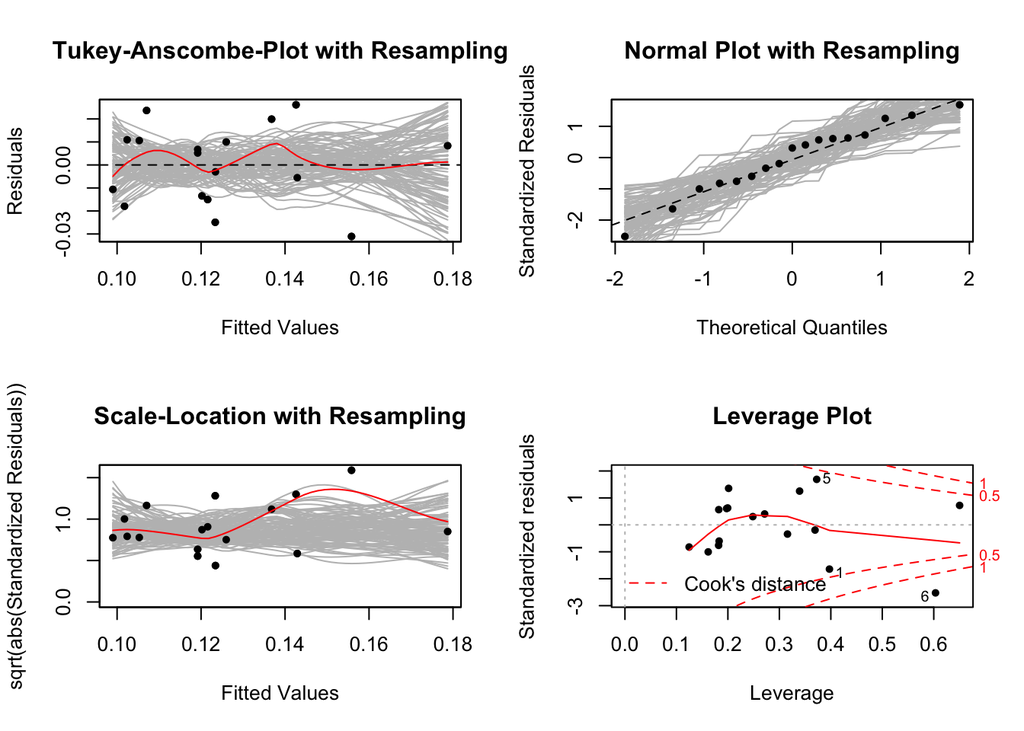

```r
resplot(full_models[["RE_amb"]][["03_selected"]])
```

```r
# Check outlier
Ren_both_effects[["wide_no_na"]] %>%
  slice(c(11))
```

| country_code | S_GAV | S_coal | S_elec | S_GDP | RE_perf | P_REN | S_potential | P_ambition | S_centr | S_size_industry | S_size_services | P_density | S_PPS | S_effort | P_support |
| --- | --- | --- | --- | --- | --- | --- | --- | --- | --- | --- | --- | --- | --- | --- | --- |
| HR | 0.001325 | 0 | 0.1862431 | 0.007888889 | 0.4985348 | 7.27 | 2.081955 | -0.03138514 | 0.8273556 | 0.2036 | 0.2221 | 0.2025316 | 60 | 0.23691 | 0.5 |

# 4. EE Ambition

## Full model construction

This model contains all possible IVs.

```r
full_models[["EE_amb"]][["01_untransformed"]] <- lm(
  P_ambition ~
    P_density + P_REN +
    S_GAV + S_potential + S_effort + S_PPS + S_elec + S_centr  + S_GDP,
  data = EE_both_effects[["wide_no_na"]])

summary(full_models$EE_amb$`01_untransformed`)
```

```
##
## Call:
## lm(formula = P_ambition ~ P_density + P_REN + S_GAV + S_potential +
##     S_effort + S_PPS + S_elec + S_centr + S_GDP, data = EE_both_effects[["wide_no_na"]])
##
## Residuals:
##       Min        1Q    Median        3Q       Max
## -0.062141 -0.032006 -0.008869  0.010775  0.124442
##
## Coefficients:
##               Estimate Std. Error t value Pr(>|t|)
## (Intercept) -4.616e-01  2.389e-01  -1.932   0.0894 .
## P_density   -7.175e-02  1.808e-01  -0.397   0.7019
## P_REN        4.750e-03  2.230e-03   2.130   0.0658 .
## S_GAV        7.235e-01  3.288e+00   0.220   0.8313
## S_potential -3.200e-04  5.182e-04  -0.617   0.5541
## S_effort    -3.338e+01  4.228e+01  -0.789   0.4526
## S_PPS        1.642e-03  1.248e-03   1.316   0.2246
## S_elec       8.950e-01  5.567e-01   1.608   0.1466
## S_centr      3.326e-01  1.142e-01   2.913   0.0195 *
## S_GDP       -1.378e+00  3.149e+00  -0.438   0.6732
## ---
## Signif. codes:  0 '***' 0.001 '**' 0.01 '*' 0.05 '.' 0.1 ' ' 1
##
## Residual standard error: 0.06726 on 8 degrees of freedom
## Multiple R-squared:  0.8569, Adjusted R-squared:  0.6959
## F-statistic: 5.323 on 9 and 8 DF,  p-value: 0.01382
```

## Collinearity check

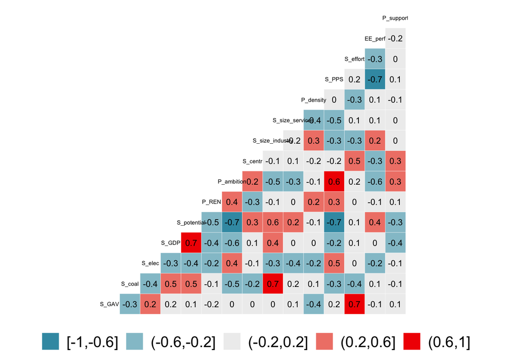

```r
GGally::ggcorr(EE_both_effects$wide_no_na, nbreaks = 5, label = TRUE, size = 2,label_size = 3, legend.position = "bottom", legend.size = 15)
```

```r
vif(full_models$EE_amb$`01_untransformed`)
```

```
##   P_density       P_REN       S_GAV S_potential    S_effort       S_PPS
##    1.343762    2.451711    3.346103    6.308542    3.746346    3.726926
##      S_elec     S_centr       S_GDP
##    2.171382    2.475005    3.275817
```

S_potential could be collinear with S_GDP

## Math variable selection

Let’s apply a stepwise backward selection of variables to the full model.

```r
full_models[["EE_amb"]][["03_selected"]] <- step(full_models[["EE_amb"]][["01_untransformed"]], direction = "backward", trace = 0)
summary(full_models[["EE_amb"]][["03_selected"]])
```

```
##
## Call:
## lm(formula = P_ambition ~ P_REN + S_potential + S_PPS + S_elec +
##     S_centr, data = EE_both_effects[["wide_no_na"]])
##
## Residuals:
##       Min        1Q    Median        3Q       Max
## -0.091309 -0.031553  0.002611  0.017406  0.114356
##
## Coefficients:
##               Estimate Std. Error t value Pr(>|t|)
## (Intercept) -0.3743216  0.1759661  -2.127  0.05482 .
## P_REN        0.0044361  0.0017406   2.549  0.02553 *
## S_potential -0.0005412  0.0003079  -1.757  0.10429
## S_PPS        0.0009933  0.0008184   1.214  0.24820
## S_elec       1.0283424  0.4468814   2.301  0.04011 *
## S_centr      0.2910557  0.0686626   4.239  0.00115 **
## ---
## Signif. codes:  0 '***' 0.001 '**' 0.01 '*' 0.05 '.' 0.1 ' ' 1
##
## Residual standard error: 0.05893 on 12 degrees of freedom
## Multiple R-squared:  0.8352, Adjusted R-squared:  0.7665
## F-statistic: 12.16 on 5 and 12 DF,  p-value: 0.0002338
```

## Checking Model assumptions

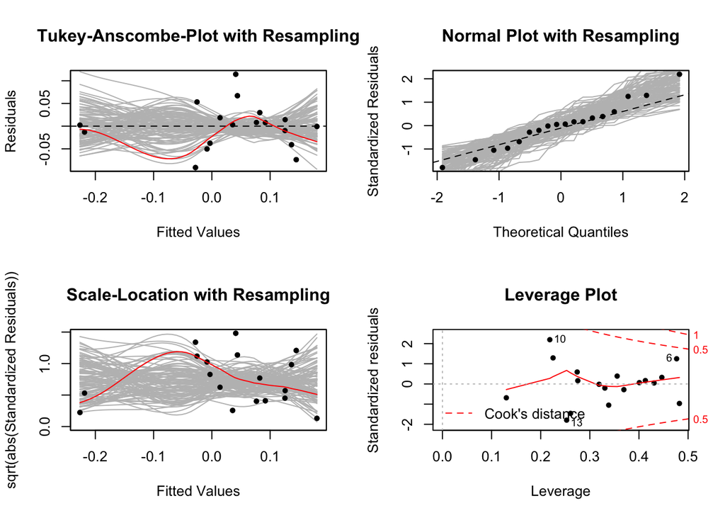

```r
resplot(full_models[["EE_amb"]][["03_selected"]])
```

These assumption plots are not ideal, but no highly influential outliers.

# Overview tables

```r
tab_model(
  full_models$RE$`03_selected`, full_models$EE$`03_selected`,
  dv.labels = c("RE performance", "EE performance"),
  pred.labels = variable_names,
  title = "Explaining REN Performance",
  p.style = "stars",
  show.std = TRUE,
  p.threshold = c(0.1, 0.05, 0.01),
  digits = 3)
```

Explaining REN Performance

RE performance

EE performance

Predictors

Estimates

std. Beta

CI

standardized CI

Estimates

std. Beta

CI

standardized CI

(Intercept)

0.166 *

-0.000

-0.017 – 0.349

-0.316 – 0.316

0.292 **

-0.000

0.056 – 0.528

-0.330 – 0.330

Target Ambition  
(NEEAP/NREAP)

-2.676 ***

-0.697

-3.982 – -1.370

-1.037 – -0.357

-0.213

-0.340

-0.547 – 0.121

-0.873 – 0.193

Spending on renewable  
support schemes

0.006 **

0.374

0.000 – 0.011

0.027 – 0.721

Technical potential

0.094 ***

0.699

0.045 – 0.143

0.337 – 1.061

-0.000 *

-0.487

-0.001 – 0.000

-1.063 – 0.089

Size of EE/REN sector

2.652

0.315

-1.351 – 6.654

-0.160 – 0.790

Historical efforts

-32.106

-0.314

-80.796 – 16.585

-0.789 – 0.162

State affluence

-0.003 ***

-0.838

-0.004 – -0.001

-1.372 – -0.304

Observations

18

18

R<sup>2</sup> / R<sup>2</sup> adjusted

0.679 / 0.610

0.709 / 0.588

- p<0.1 ** p<0.05 *** p<0.01

```r
tab_model(
  full_models$RE_amb$`03_selected`, full_models$EE_amb$`03_selected`,
  dv.labels = c("RE ambition", "EE ambition"),
  pred.labels = variable_names,
  title = "Explaining REN Ambition",
  p.style = "stars",
  show.std = TRUE,
  p.threshold = c(0.1, 0.05, 0.01),
  digits = 3)
```

Explaining REN Ambition

RE ambition

EE ambition

Predictors

Estimates

std. Beta

CI

standardized CI

Estimates

std. Beta

CI

standardized CI

(Intercept)

0.065 **

0.000

0.017 – 0.114

-0.381 – 0.381

-0.374 *

-0.000

-0.758 – 0.009

-0.248 – 0.248

Size of EE/REN sector

-3.235

-0.392

-8.070 – 1.601

-0.977 – 0.194

Technical potential

0.013 **

0.655

0.002 – 0.025

0.097 – 1.214

-0.001

-0.351

-0.001 – 0.000

-0.786 – 0.084

Historical efforts

0.101

0.411

-0.049 – 0.251

-0.199 – 1.022

State affluence

0.000 *

0.390

-0.000 – 0.001

-0.028 – 0.807

0.001

0.206

-0.001 – 0.003

-0.163 – 0.574

Spending on renewable  
support schemes

0.004 **

0.417

0.001 – 0.008

0.060 – 0.773

Electricity available for  
final consumption

1.028 **

0.364

0.055 – 2.002

0.019 – 0.709

Centralization of the  
electricity market.

0.291 ***

0.536

0.141 – 0.441

0.261 – 0.812

Observations

17

18

R<sup>2</sup> / R<sup>2</sup> adjusted

0.609 / 0.479

0.835 / 0.767

- p<0.1 ** p<0.05 *** p<0.01